# A3: Incarceration

##### 2036461

##### 2/25/2022

### Introduction

The incarceration rate in the U.S. has always been an important topic. The institution Vera Institute collected and presented a data set that provides some insights of the problem. Since the data set include multiple information like gender and race of the prisoners all over the U.S. from 1970 to 2018, the main problem domain I want to analyze in this data set is centered around the relationship between sates, population in jail, race and total population. The main questions I asked are how does the total population varies through year in different states, how does the rate of population in prison of different race correlates with the total population in prison, and what the jail population in each state is like in 2010?

The main variables I chose to analyze are:

1. Year: There are many trends with respect to the change of year. As we could see from the data set, almost numbers varies through year. So, year would be a really important elements when analyzing different trends in this data set.
2. Total population: When analyzing the jail population in each states, it is also important to know the total population in each state so we could conclude if there’s certain correlations between them.
3. State: Since all the rows in the data set contains which state the data is from, state would be an important variable to study because we could conclude what the general data of each state is like and how they correlate.
4. White prison rate: Since the data set contains multiple data about race, it would be important to know how the data varies between each race. Since white takes up a large proportion of population, it would be an important variable to study.
5. Black prison rate: Since the data set contains multiple data about race, it would be important to know how the data varies between each race. Since black takes up a large proportion of population, it would be an important variable to study.
6. Latinx prison rate: Since the data set contains multiple data about race, it would be important to know how the data varies between each race. Since latinx takes up a large proportion of population, it would be an important variable to study.

### The Dataset

The data was collected by the U.S. Department of Justice Bureau of Justice Statistics (BJS) and supplemented with data from state departments of correction. The data was collected by the NCRP, ASJ, COJ, and DCRP through recording the detailed individual-level data on admissions and releases from state prison authorities, including county of commitment. The data was collected because they want to have a detailed understanding of the prison related variables and use the data to generate a visualization. There are 153811 rows in total and 121 columns in total. The ethical question might be about data privacy. When dealing with the dataset, we should avoid analyzing the data by each row because that might reveal the information of certain prisoners. There are also multiple limitations in this data set. The first possible limitation is that since the data set combines data from different sources, their method of collecting data might be different, which might cause the datas to be in different format. If the data is not well analyzed and cleaned, the data set might contain inaccurate data. Also, the NAs in the data set make many rows not applicable, which will make it harder for people to compare in the data set.

### Trends Over Time Chart

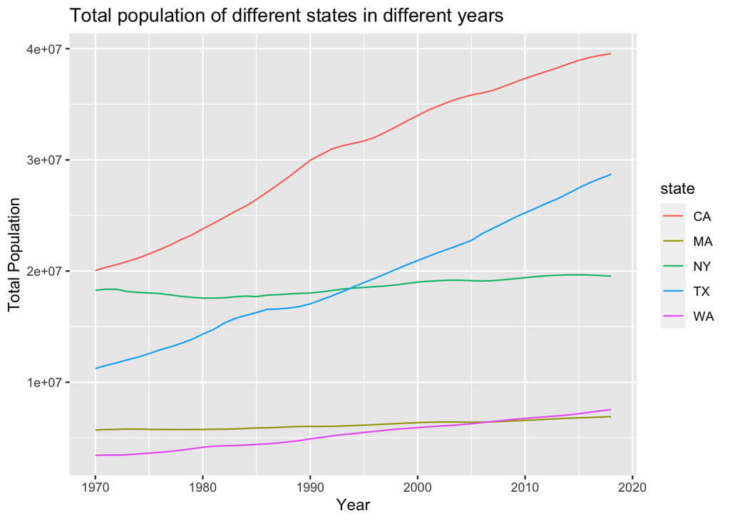

This chart shows how the total population of states like “CA”, “MA”, “NY”, “TX”, and “WA” varies from 1970 to 2018. These states are chosen since they are the states I traveled to on my first trip to the U.S. I used line chart for this one because it could show how the population varies through year and the comparison between each state clearly. Each line represents the change of total population in a state and has different colors to make it clearer. It’s obvious that “CA”, “TX”, and “WA” show a clear pattern of increase in the total population, while the line of “NY” and “MA” are relatively flat, showing that the total population of those states does not increase much. The possible reason of this situation is that “NY” and “MA” has relatively large population base so there’s not enough room for population increase, while other states are still developing and have relatively large potention for population to increase.

### Variable Comparison Chart

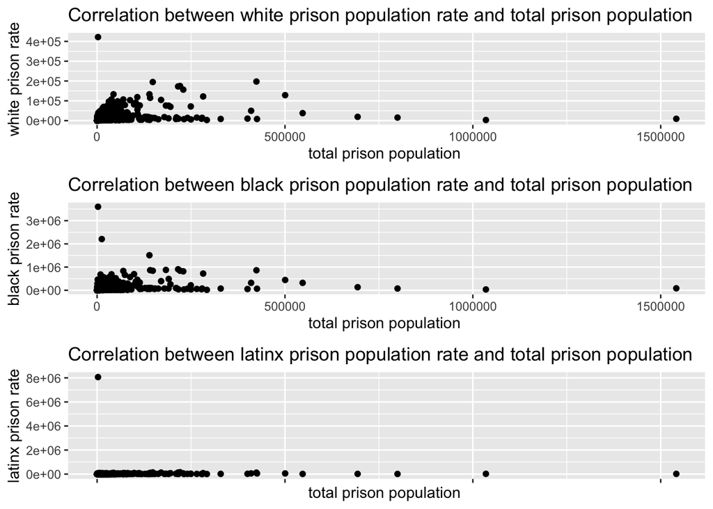

### Map

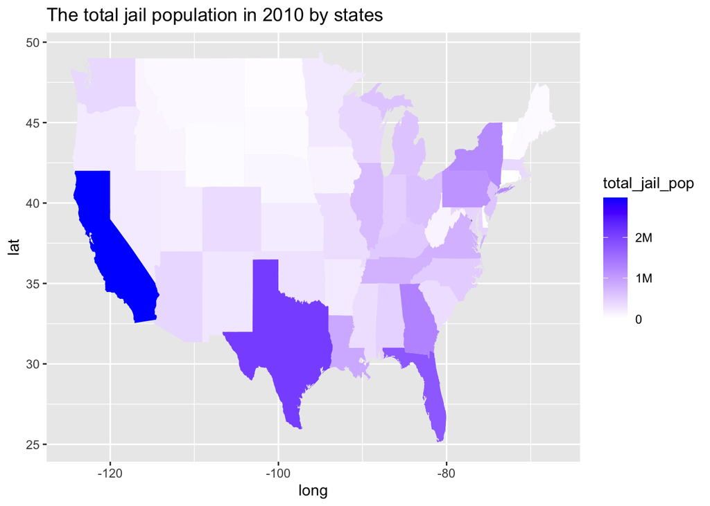

What I include in the chart is how the total jail population differs in each state in 2010. I used map for this one because it could compare the total prison population most clearly. I used the white to blue color scale because it could present the difference between each state obviously. It is obvious that “CA” has the largest total jail population in 2010, while the middle part of the US like “MT” and “WY” has the least total jail population in 2010. “WA” also has relatively small total jail population in 2010.